### Enrollment and Spending

**Managed Long Term Care Enrollment and Spending, by Fiscal Year**

New York State (Since April 2014)

| Fiscal Year | Months Reported | Enrollee Months, by Plan Type MAP | Enrollee Months, by Plan Type PACE | Enrollee Months, by Plan Type MLTC | Total Enrollment Enrollee Months | Total Enrollment Average Monthly Change % | Total Enrollment Annual Change | Total Enrollment Annual Change % | Total Enrollment End of Period Enrollment | State Spending Spending | State Spending Annual Change | State Spending Annual Change % | Average Annual Spending per Enrollee Average Monthly Number of Enrollees | Average Annual Spending per Enrollee Spending | Average Annual Spending per Enrollee Annual Change | Average Annual Spending per Enrollee Annual Change % |
| --- | --- | --- | --- | --- | --- | --- | --- | --- | --- | --- | --- | --- | --- | --- | --- | --- |
| FY27 (Estimate) | NA | 997,188 | 120,984 | 3,354,292 | 4,472,464 | NA | −47,539 | −1.1% | 372,705 | NA | NA | NA | 374,686 | NA | NA | NA |
| FY27 (YTD) | 3 | 249,297 | 30,246 | 838,573 | 1,118,116 | −0.4% | NA | NA | 372,030 | NA | NA | NA | 372,705 | NA | NA | NA |
| FY26 | 12 | 852,512 | 117,088 | 3,550,403 | 4,520,003 | 0.1% | 154,643 | 3.5% | 376,949 | NA | NA | NA | 376,667 | NA | NA | NA |
| FY25 | 12 | 627,099 | 116,883 | 3,621,378 | 4,365,360 | 1.1% | 465,499 | 11.9% | 373,961 | $9,728,000,000 | $863,000,000 | 9.7% | 363,780 | $26,741 | −$536 | −2.0% |
| FY24 | 12 | 495,854 | 111,731 | 3,292,276 | 3,899,861 | 1.0% | 367,152 | 10.4% | 333,060 | $8,865,000,000 | $1,251,000,000 | 16.4% | 324,988 | $27,278 | $1,414 | 5.5% |
| FY23 | 12 | 417,691 | 92,371 | 3,022,647 | 3,532,709 | 0.6% | 182,444 | 5.4% | 300,026 | $7,614,000,000 | −$83,000,000 | −1.1% | 294,392 | $25,863 | −$1,706 | −6.2% |
| FY22 | 12 | 359,128 | 67,561 | 2,923,576 | 3,350,265 | 0.3% | 58,282 | 1.8% | 281,667 | $7,697,000,000 | $482,000,000 | 6.7% | 279,189 | $27,569 | $1,269 | 4.8% |
| FY21 | 12 | 274,950 | 66,683 | 2,950,350 | 3,291,983 | −0.0% | 84,031 | 2.6% | 272,732 | $7,215,000,000 | −$550,000,000 | −7.1% | 274,332 | $26,300 | −$2,746 | −9.5% |
| FY20 | 12 | 212,188 | 69,079 | 2,926,685 | 3,207,952 | 1.2% | 391,595 | 13.9% | 274,097 | $7,765,000,000 | $1,480,000,000 | 23.5% | 267,329 | $29,047 | $2,267 | 8.5% |
| FY19 | 12 | 147,375 | 68,798 | 2,600,184 | 2,816,357 | 1.3% | 358,795 | 14.6% | 242,484 | $6,285,000,000 | $473,000,000 | 8.1% | 234,696 | $26,779 | −$1,600 | −5.6% |
| FY18 | 12 | 102,662 | 68,264 | 2,286,636 | 2,457,562 | 1.4% | 357,018 | 17.0% | 211,642 | $5,812,000,000 | $1,200,000,000 | 26.0% | 204,797 | $28,379 | $2,032 | 7.7% |
| FY17 | 12 | 75,216 | 67,232 | 1,958,096 | 2,100,544 | 2.0% | 364,480 | 21.0% | 182,251 | $4,612,000,000 | $819,000,000 | 21.6% | 175,045 | $26,347 | $130 | 0.5% |
| FY16 | 12 | 72,207 | 65,801 | 1,598,056 | 1,736,064 | 0.7% | 114,229 | 7.0% | 149,436 | $3,793,000,000 | $322,000,000 | 9.3% | 144,672 | $26,218 | $536 | 2.1% |
| FY15 | 12 | 68,842 | 67,387 | 1,485,606 | 1,621,835 | 1.1% | NA | NA | 139,204 | $3,471,000,000 | NA | NA | 135,153 | $25,682 | NA | NA |

**Data Sources:** New York State Department of Health Medicaid Managed Care Enrollment Reports, and Medicaid Global Spending Cap Updates  
**Data as of:** August 01, 2026

The interactive Excel workbook allows users to enter growth-rate predictions, and model projections.  
**Data Sources:** New York State Department of Health [Medicaid Managed Care Enrollment Reports](https://www.health.ny.gov/health_care/managed_care/reports/enrollment/monthly/), and [Medicaid Global Spending Cap Updates](https://www.health.ny.gov/health_care/medicaid/regulations/global_cap/)

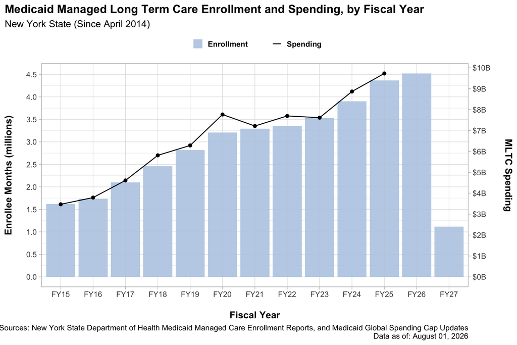

**Data Sources:** New York State Department of Health [Medicaid Managed Care Enrollment Reports](https://www.health.ny.gov/health_care/managed_care/reports/enrollment/monthly/), and [Medicaid Global Spending Cap Updates](https://www.health.ny.gov/health_care/medicaid/regulations/global_cap/)

### Technical Notes

1. *MLTC* = Partial cap managed long term care.
2. Spending data in this analysis are based on the amounts reported under the ‘Long Term Managed Care’ category in the New York State Medicaid Global Cap Reports. This category reflects state-reported expenditures specific to Medicaid Managed Long-Term Care programs.
3. Data for FY12 through FY14 are not presented in the enrollment vs. spending analysis because no spending was reported on the ‘Long Term Managed Care’ line in the New York State Medicaid Global Cap Reports during those years. As a result, the analysis begins with FY15, the first year for which spending on that line was reported.

### Definitions

- **Fiscal Year:** April through March
- **Enrollee Months:** The total number of Medicaid managed long term care enrollee months reported within the fiscal year.
- **End of Period Enrollment:** The total number of Medicaid managed long term care enrollees at the end of the reporting period. For completed fiscal years, this represents the enrollment total on the final day of the year. For partial fiscal years, it reflects the year-to-date (YTD) enrollment total as of the most recent reporting date.
- **Average Monthly Change %:** For each row’s respective fiscal year, this column calculates each month’s enrollment delta percentage (i.e., *[(that month’s enrollment) - (previous month’s enrollment)] / (previous month’s enrollment))* and then reports the mean of those twelve percentages.
- **Enrollee Months Annual Change:** The difference in the total number of enrollee months between the current fiscal year and the prior fiscal year.
- **Enrollee Months Annual Change %:** The percentage increase or decrease in the total enrollee months compared to the prior fiscal year.
- **State Spending:** The total Medicaid managed long term care expenditures by the State government.
- **State Spending Annual Change:** The year-over-year change in State spending on Medicaid managed long term care.
- **State Spending Annual Change %:** The percentage change in the State’s share of Medicaid managed long term care spending compared to the prior fiscal year.
- **Average Annual Spending per Enrollee:** The average amount of Medicaid managed long term care State spending per enrollee for the fiscal year.
- **Average Annual Spending per Enrollee Annual Change:** The year-over-year change in the average amount of State spending per enrollee, expressed in dollars.
- **Average Annual Spending per Enrollee Annual Change %:** The percentage growth in State Medicaid spending per-capita compared to the prior fiscal year.